# Efeito das Políticas Públicas sobre a variação quantitativa de Pessoas em Situação de Rua no Distrito Federal no ano 2023

Hernany Gomes de Castro

2024-07-04

# Introdução

O trabalho apresenta estimativas intervalares para algumas variáveis das políticas públicas de saúde, assistência social e de resíduos sólidos, relacionadas, direta ou indiretamente, à variação quantitativa de pessoas em situação de rua no Distrito Federal no ano 2023. O objetivo é estimar intervalos para as variáveis escolhidas, com 95% de confiança, para atender a requisito da disciplina de pós-graduação, Metodologia Quantitativa em Ciência Política, do Instituto de Ciência Política - Ipol/Unb. A proposta é verificar como ações dessas políticas públicas, à exemplo da Abordagem Social, Consultório na Rua e Coleta Seletiva e não Seletiva de Resíduos, podem ter influenciado o aumento e a diminuição da quantidade de pessoas em situação de rua no DF durante o período.

- Observação: o trabalho está em andamento.

# Pessoa em Situação de Rua Ativa

Pessoa em Situação de Rua Ativa é uma classificação realizada pelo Serviço Especializado de Abordagem Social (SEAS), da Secretaria de Estado de Desenvolvimento Social do DF (SEDES), que consiste na contagem de pessoas atendidas em um ponto de concentração e encontradas em outro ponto na cidade, embora sem novo atendimento. Em outras palavras, são pessoas conhecidas e atendidas encontradas em um novo local que não aquele onde o atendimento foi realizado. Essa definição é de interesse para a pesquisa por indicar a circulação da população em situação de rua.

# Variáveis Independentes

- **“abordagem_razao”**: total de abordagens sociais realizadas pelo Serviço Especializado de Abordagem Social para cada 100 habitantes do DF.
- **“ecr_razao”**: total de atendimentos realizados pelas equipes do Consultório na rua para cada 100 habitantes do DF.
- **“residuos_razao”**: total de kilos de resíduos coletados pelo Serviço de Limpeza Urbana (SLU) para cada 100 habitantes do DF.
- **“seletiva_razao”**: total de kilos de resíduos coletados na coleta seletiva pelo SLU para cada 100 habitantes do DF.

Para fins de comparação, calculou-se a razão das variáveis em relação à população do Distrito Federal, com base no Censo IBGE 2022, na escala de 1 (um) unidade da variável para cada 100 (cem) habitantes do DF. A abrangência da estimativa é Distritro Federal.

# Estimativa Intervalar para as Variáveis Independentes

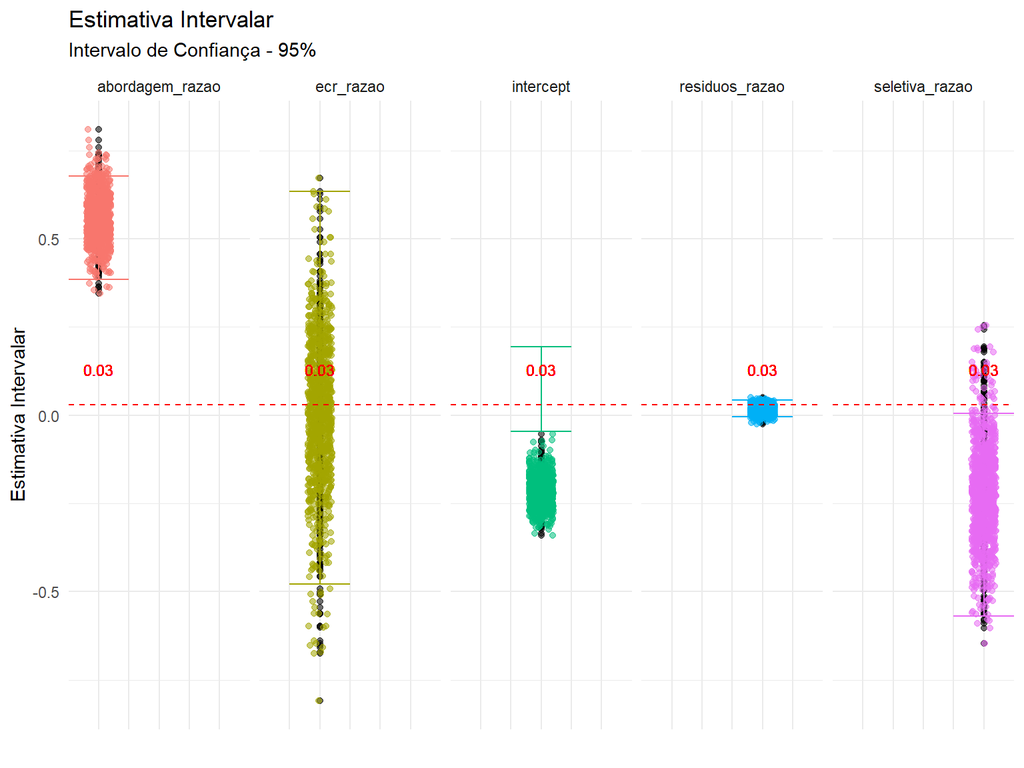

# Análise

# Hipóteses

1. O efeito das variáveis **“abordagem_razao”**, **“ecr_razao”**, **“residuos_razao”** e **“seletiva_razao”**, difere segundo os territórios de renda categorizados pelo IPEDF-DIEESE (2024). Propõe-se que a análise do efeito pode ser melhor captada se a área de abrangência utilizada (DF) for desagregada.
2. O aumento de **“abordagem_razao”** e **“ecr_razao”** gera os seguintes efeitos nos territórios sugeridos: a) redução nos grupos de alta e média-alta renda; b) aumento nos grupos de média-baixa e baixa renda.
3. O aumento de **“seletiva_razao”** gera os seguintes efeitos nos territórios sugeridos: a) aumento nos grupos de alta e média-alta renda; b) redução nos grupos de média-baixa e baixa renda.
4. O aumento de **“residuos_razao”** gera os seguintes efeitos nos territórios sugeridos: aumento nos grupos de alta e média-alta renda, como nos grupos de média-baixa e baixa renda.